# 논문조사 및 문헌정리

‘수학과 201521139 이재학’

2022-02-23

##### **라이브러리 설치**

```r
#install.packages('pracma')                 #Hausdorff Distance
#install.packages('dtw')                    #DTW
#install.packages('SimilarityMeasures')     #Frechet Distance
#install.packages('TSdist')                 #Frechet Distance
#install.packages('trajectories')           #Discrete Frechet Distance
#install.packages('tictoc')                 #시간측정
#install.packages('ggplot2')                #데이터시각화
#install.packages('glue')                   #Like Python f-string
#install.packages('rgl')                    #3차원 plot
#install.packages('scatterplot3d')          #3차원 scatterplot
```

##### **라이브러리 불러오기**

```r
library(pracma)
library(dtw)
library(SimilarityMeasures)
library(TSdist)
library(trajectories)
library(tictoc)
library(ggplot2)
library(glue)
library(rgl)
library(scatterplot3d)
```

##### **Eulcidean Distance 사용자 함수 정의**

```r
euclidean <- function(a, b) sqrt(sum((a - b)^2))
```

##### **데이터 불러오기 -> 사용자에 맞게 주소 수정 필요!**

```r
climate_seoul<-read.csv('C:/Users/이재학/Desktop/climate.csv')
climate_multi<-read.csv('C:/Users/이재학/Desktop/climate_multi.csv')
```

**데이터 : 2009년 서울의 기상**  
**2009-01-01 ~ 2009-12-31 24시**  
**1시간마다의 기온,강수량,풍속,풍향,습도 등등 측정**

```r
head(climate_seoul)
```

```
##              date Temp
## 1 2009-01-01 0:00 -7.6
## 2 2009-01-01 1:00 -7.8
## 3 2009-01-01 2:00 -8.1
## 4 2009-01-01 3:00 -8.5
## 5 2009-01-01 4:00 -8.8
## 6 2009-01-01 5:00 -9.0
```

```r
head(climate_multi)
```

```
##              date temp  X wind_power wind_direction moisture
## 1 2009-01-01 0:00 -7.6 NA        2.1            290       55
## 2 2009-01-01 1:00 -7.8 NA        2.3            320       54
## 3 2009-01-01 2:00 -8.1 NA        2.0            340       52
## 4 2009-01-01 3:00 -8.5 NA        2.4            290       52
## 5 2009-01-01 4:00 -8.8 NA        2.1            320       53
## 6 2009-01-01 5:00 -9.0 NA        1.7            340       55
```

**시계열 데이터 분석을 위해 1월 vs 2월의 기온(1차원 데이터)비교**

```r
jan<-climate_seoul[c(1:747),]
feb<-climate_seoul[748:1419,]
tail(jan)
```

```
##                 date Temp
## 742 2009-01-31 18:00  8.7
## 743 2009-01-31 19:00  7.3
## 744 2009-01-31 20:00  6.3
## 745 2009-01-31 21:00  5.3
## 746 2009-01-31 22:00  4.7
## 747 2009-01-31 23:00  4.0
```

```r
tail(feb)
```

```
##                  date Temp
## 1414 2009-02-28 18:00  8.3
## 1415 2009-02-28 19:00  6.7
## 1416 2009-02-28 20:00  5.7
## 1417 2009-02-28 21:00  5.6
## 1418 2009-02-28 22:00  5.7
## 1419 2009-02-28 23:00  5.1
```

##### **데이터 시각화**

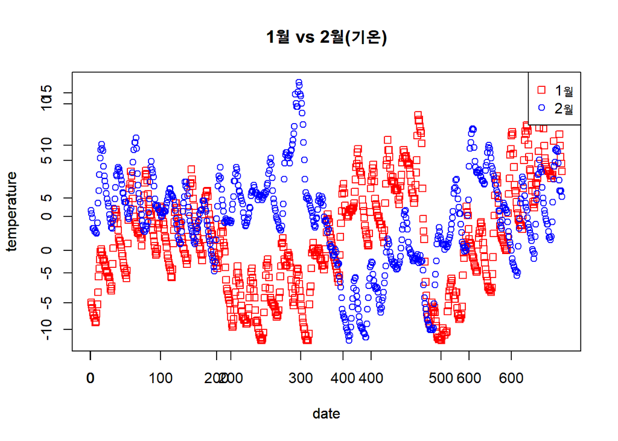

```r
plot(jan[,2],col='red',main='1월 vs 2월(기온)',xlab='date',ylab='temperature',pch=0)
par(new=TRUE)
plot(feb[,2],col='blue',main='1월 vs 2월(기온)',xlab='date',ylab='temperature',pch=1)
legend(x='topright',legend=c("1월","2월"),col=c("red","blue"),pch=c(0,1))
```

##### **1월의 기온이 상대적으로 낮고, 일수가 1월이 더 길기에 데이터 길이가 다름**

##### **Hausdorff Distance**

```r
hausdorff_dist(jan[,2],feb[,2])
```

```
## [1] NA
```

```r
summary(jan[,])
```

```
##      date                Temp
##  Length:747         Min.   :-11.000
##  Class :character   1st Qu.: -5.400
##  Mode  :character   Median : -2.250
##                     Mean   : -1.961
##                     3rd Qu.:  1.300
##                     Max.   : 11.900
##                     NA's   :3
```

##### **1월의 경우 결측치가 3개 있어서 분석 불가능 -> 결측치 : 평균값으로 대체**

```r
hd_jan<-jan[,2]
hd_jan[is.na(hd_jan)]<-mean(hd_jan,na.rm=TRUE)
start_time<-Sys.time()
hausdorff_dist(hd_jan,feb[,2])
```

```
## [1] 4.1
```

```r
end_time<-Sys.time()

glue('Hausdorff Distance 거리 값 : {hausdorff_dist(hd_jan,feb[,2])} , 실행 시간 : {end_time-start_time}')
```

```
## Hausdorff Distance 거리 값 : 4.1 , 실행 시간 : 0.157366991043091
```

##### **Euclidean Distance**

```r
euclidean(jan[,2],feb[,2])
```

```
## [1] NA
```

##### **1월이 2월보다 일자가 더 길기에, 데이터의 갯수를 맞춰야 함!**

##### **마찬가지로 NA값 평균 대체한 데이터로 측정**

```r
ed_jan<-hd_jan[1:672]
start_time<-Sys.time()
e_d<-euclidean(ed_jan,feb[,2])
end_time<-Sys.time()
glue('Euclidean Distance 거리 값 : {e_d} , 실행 시간 : {end_time-start_time}')
```

```
## Euclidean Distance 거리 값 : 230.976285947503 , 실행 시간 : 0.0139541625976562
```

##### **DTW**

```r
jan<-climate_seoul[1:747,2]
feb<-climate_seoul[748:1419,2]
dtw_jan<-jan
dtw_jan[is.na(dtw_jan)]<-mean(dtw_jan,na.rm=TRUE)
start_time<-Sys.time()
dtwdistance<-dtw(dtw_jan,feb)
end_time<-Sys.time()
glue('DTW 거리 값 : {dtwdistance$distance} , 실행 시간 : {end_time-start_time}')
```

```
## DTW 거리 값 : 2008.01733870968 , 실행 시간 : 0.109704971313477
```

##### **Frechet Distance**

```r
options(max.print=1)
jan<-climate_seoul[1:747,2]
feb<-climate_seoul[748:1419,2]
fd_jan<-jan
fd_jan[is.na(fd_jan)]<-mean(fd_jan,na.rm=TRUE)
start_time<-Sys.time()
fd_distance<-FrechetDistance(fd_jan,feb)
```

[output not shown]

[output cut: 132 more lines]

[output not shown]

```r
end_time<-Sys.time()
glue('Frechet Distance 거리 값 : {fd_distance} , 실행 시간 : {end_time-start_time}')
```

```
## Frechet Distance 거리 값 : 16.1644672043343 , 실행 시간 : 27.4021508693695
```

##### **Discrete Frechet Distance**

```r
jan<-climate_seoul[1:747,2]
feb<-climate_seoul[748:1419,2]
dfd_jan<-jan
dfd_jan[is.na(dfd_jan)]<-mean(dfd_jan,na.rm=TRUE)
dfd_jan<-data.frame(dfd_jan,y=c(1:length(dfd_jan)))
feb<-data.frame(feb,y=c(1:length(feb)))
date1 <- seq(as.POSIXct("2009-1-1 0:00"), as.POSIXct("2009-1-31 23:00"), by = "hour")
date2 <- seq(as.POSIXct("2009-2-1 0:00"), as.POSIXct("2009-2-28 23:00"), by = "hour")
dfd_jan<-as.Track(dfd_jan$dfd_jan,dfd_jan$y,date1)
feb<-as.Track(feb$feb,feb$y,date2)
start_time<-Sys.time()
dfd_distance<-frechetDist(dfd_jan,feb)
end_time<-Sys.time()
glue('Discrete Frechet Distance 거리 값 : {dfd_distance} , 실행 시간 : {end_time-start_time}')
```

```
## Discrete Frechet Distance 거리 값 : 743.004205910034 , 실행 시간 : 0.881387948989868
```

##### **DTW Multi**

```r
jan_multi<-climate_multi[1:747,c("temp","wind_power","wind_direction","moisture")]
feb_multi<-climate_multi[748:1419,c("temp","wind_power","wind_direction","moisture")]
jan_multi<-na.omit(jan_multi)
feb_multi<-na.omit(feb_multi)
start_time<-Sys.time()
dtw_multi_distance<-dtw(jan_multi,feb_multi)
end_time<-Sys.time()
glue('DTW_multi 거리 값 : {dtw_multi_distance$distance} , 실행 시간 : {end_time-start_time}')
```

```
## DTW_multi 거리 값 : 47375.732863482 , 실행 시간 : 0.119195938110352
```

# 참고 링크

## <라이브러리>

[Discrete Frechet Distance](https://www.rdocumentation.org/packages/trajectories/versions/0.2-3/topics/frechetDist)  
[Frechet Distance](https://www.rdocumentation.org/packages/SimilarityMeasures/versions/1.4/topics/Frechet)  
[DTW](https://cran.r-project.org/web/packages/dtw/index.html)  
[Hausdorff Distance](https://www.rdocumentation.org/packages/pracma/versions/1.9.9/topics/hausdorff_dist)

## <기타>

[실행시간 측정 in R](https://didalsgur.tistory.com/entry/R-%EB%8F%99%EC%9E%91-%EC%8B%9C%EA%B0%84-running-time-%EA%B3%84%EC%82%B0-5%EA%B0%80%EC%A7%80-%EB%B0%A9%EB%B2%95)

## <논문>

### 메인

[computing the frechet distance between polygonal curves : 선택한 논문, Frechet Distance](https://www.worldscientific.com/doi/abs/10.1142/S0218195995000064)

### Frechet Distance 관련

[다차원 프레셰 거리 기반 종단자료 군집분석 : 교수님 및 선배님 논문](https://dcoll.ajou.ac.kr/dcollection/srch/srchDetail/000000030579)  
[대립생성망의 성능 비교에 관한 연구 : FID(Frechet inception distance](https://www.dbpia.co.kr/Journal/articleDetail?nodeId=NODE07540262)  
[이산 프레셰 거리 척도를 이용한 궤적 유사도 고속계산 휴리스틱 알고리즘 : Frechet Distance 속도 개선 알고리즘 및 간단 설명](https://www.dbpia.co.kr/Journal/articleDetail?nodeId=NODE06648726) [The Frechet distance between Multivariate Noraml Distributions : Multinomial 에서Frechet distance](https://www.sciencedirect.com/science/article/pii/0047259X8290077X)

### DTW 관련

[Computing and Visualizing Dynamic Time Warping Alignments in R The dtw Package : R이용한 DTW 설명 및 함수 구현](https://www.jstatsoft.org/article/view/v031i07)

### 유사도 비교

[Trajectory similarity measure : 궤적 유사도 비교](https://dl.acm.org/doi/abs/10.1145/2782759.2782767?casa_token=qb7UgPmNj8gAAAAA:SXaxwuIYGoqILUgBOlaj33FbXw9el2PK0pPANBpD6HmojL9Z4h_7f-LmfK5m1swObFWhSdtqDWYf8g)  
[Review on trajectory similarity measures : 유사도들비교 및 TSM 논문 리뷰 관련](https://ieeexplore.ieee.org/abstract/document/7397286)  
[products of Euclidean metrics and applications to proximity questions among curves : dfd vs DTW](https://arxiv.org/abs/1712.06471)

### 기타

[Interpoint distances : Applications, properties, and visualization : interpoint disctance](https://onlinelibrary.wiley.com/doi/abs/10.1002/asmb.2508)

# <참고한 개념>

#### Hausdorff distance

[Hausdorff distance](https://progworks.tistory.com/72)  
[Hausdorff distance 개념](https://dhpark1212.tistory.com/entry/Hausdorff-Distance)  
[Template Matching](https://velog.io/@codren/%ED%85%9C%ED%94%8C%EB%A6%BF-%EB%A7%A4%EC%B9%AD)

#### Dynamic Time Warping

[DTW Youtube](https://www.youtube.com/watch?v=03J4xzymOWM)  
[DTW tistory1](https://hamait.tistory.com/862)  
[DTW tistory2](https://leo-bb.tistory.com/58)  
[Computing DTW](https://www.youtube.com/watch?v=_K1OsqCicBY)  
[DTW 계산 설명](https://hwa-a-nui.tistory.com/2)  
[DTW 함수 옵션1](https://dynamictimewarping.github.io/py-api/html/api/dtw.dtw.html)  
[DTW 함수 옵션2_깃허브](https://github.com/DynamicTimeWarping/dtw-python/blob/master/dtw/dtwPlot.py)

#### Frechet distance

[유튜브 : Frechet Distance Between Two Point Sets](https://www.youtube.com/watch?v=12vrDDBnEFg)  
[위키피디아](https://en.wikipedia.org/wiki/Fr%C3%A9chet_distance)  
[유튜브 : GAN 성능의 정량적 평가 방법 - Python, Deep Learning](https://www.youtube.com/watch?v=19An2T4utEM)

##### **참고사항**

- 데이터의 결측치는 평균값 대체
- SimilarityMeasures 패키지의 Frechet Distance는 input이 matrix여야하고, 너무 느려서 TSdist로 대체
- Frechet Distance 출력 함수가 너무 길어서 print max option 적용
- Discrete Frechet Distance -> 적절한 라이브러리 찾기 어려움
  - 1.trajectories 라이브러리 : Track object로 변환해야 함! (이거로) -> 파이썬으로 적용했던 값과 큰 차이..
  - 2.Python in R : R에서 쓰는 파이썬 스크립트
- DTW multi 에서는 결측치 제거

##### **R VS Python**

[output not shown]

- 파이썬 코드로는 결측치 제거, R에서는 결측치 평균값 대체(DTW_multi는 결측치 제거)
- Hausdorff distance의 경우 R과 파이썬의 알고리즘이 다름 -> 거리,출력 형태 다름
- 거리 값과 실행시간의 경우 유효숫자 고려한 반올림
- DTW의 경우 R 기반으로 하여 파이썬으로 확장하였기에 비슷함
- 나머지 거리기준의 경우, 실행하는 코드의 알고리즘에 따라 다를 수 있음
- 전반적으로, 파이썬 코드의 실행시간이 더 빠르다.
  - [R vs Python 실행시간 관점](https://yozm.wishket.com/magazine/detail/1178/)
- 라이브러리 불러올 때, 경고 해결하기
  - [(R마크다운) knitr::chunk 경고 메시지 없애기 (warning, message)](https://bpapa.tistory.com/47)